# Final exam 2021-22

### Univariate and Bivariate statistics

```r
library("FactoMineR")
library("factoextra")
library("datasets")
```

Let us consider the *hobbies* dataset, available from *FactoMineR*.

```r
data(hobbies)
names(hobbies)
```

```
##  [1] "Reading"         "Listening music" "Cinema"          "Show"
##  [5] "Exhibition"      "Computer"        "Sport"           "Walking"
##  [9] "Travelling"      "Playing music"   "Collecting"      "Volunteering"
## [13] "Mechanic"        "Gardening"       "Knitting"        "Cooking"
## [17] "Fishing"         "TV"              "Sex"             "Age"
## [21] "Marital status"  "Profession"      "nb.activitees"
```

The data used here concern a questionnaire on hobbies. 8403 individuals were asked to answer questions about their hobbies (18 questions). The following four variables were used to describe the individuals: sex (male, female), age (15-25, 26-35, 36-45, 46-55, 56-65, 66-75, 76-85, 86-100), marital status (single, married, widowed,divorced, remarried), profession (manual laborer, unskilled worker, technician, foreman, senior management, employee, other). And finally, a quantitative variable indicates the number of hobbies practiced out of the 18 possible choices.

1. Let us focus on the variable *Profession*. Create a frequency distribution for this categorical variable (try the function *table()*). Save the distribution you created with the name *Pro_distr*. Which one is the most occurring category (i.e. the mode of the variable *Profession*)?

```r
#Create a frequency distribution

freq <- table(hobbies$Profession)
print(freq)
```

```
##
## Unskilled worker  Manual labourer       Technician          Foreman
##              792             1161              401              735
##       Management         Employee            Other
##             1052             2552              212
```

```r
Pro_distr <- prop.table(freq)
print(Pro_distr)
```

```
##
## Unskilled worker  Manual labourer       Technician          Foreman
##       0.11469949       0.16813903       0.05807386       0.10644461
##       Management         Employee            Other
##       0.15235337       0.36958726       0.03070239
```

```r
#The most occurring category is Employee. This is the mode of the variable Profession.
```

2. Using the distribution you just created, make a bar plot and a pie chart (the functions you need are *barplot()* and *pie()*).

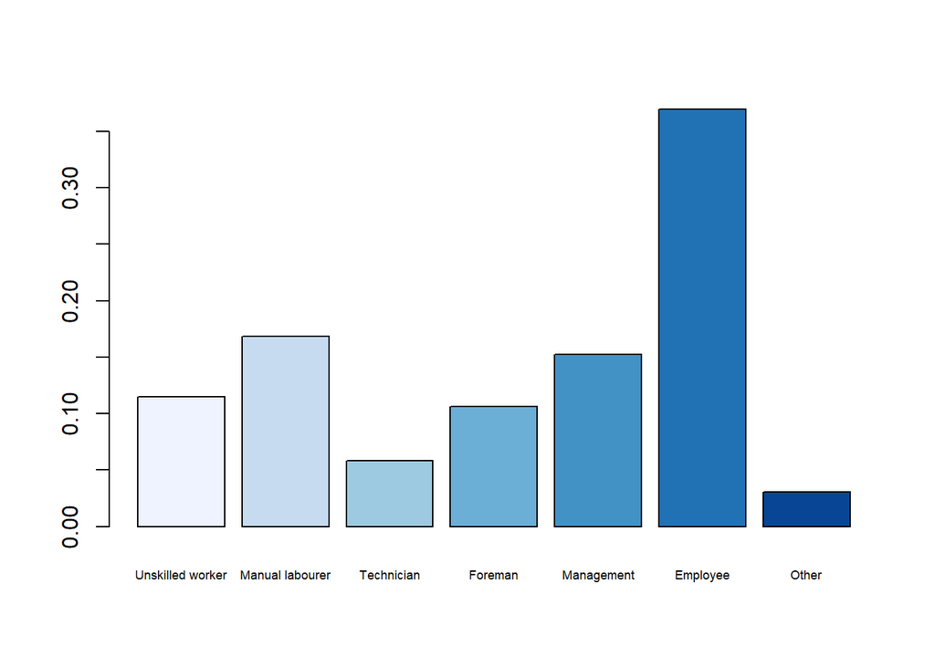

```r
#Making a bar plot and a pie chart

library(RColorBrewer)
coul <- brewer.pal(7,'Blues')
barplot(Pro_distr, width = 0.6, cex.names = 0.55, col = coul)
```

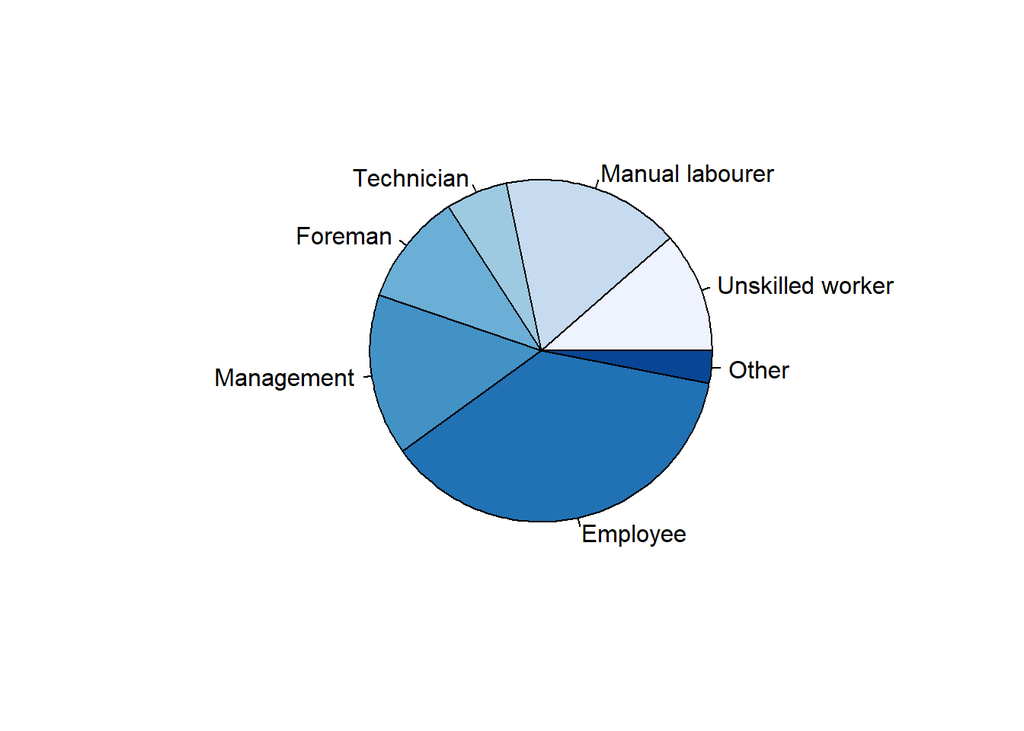

```r
pie(Pro_distr, col = coul)
```

3. Let us consider the joint distribution of *Profession* and two different hobbies, *Cinema* and *Reading*. Save this two cross-tables in your worspace as *Pro_Cine* and *Pro_Read*. In each of this table you have a ‘1’ if the respondents has that particular hobbie, ‘0’ otherwise.

```r
#Frequency of People, considering Professions Category that has Cinema or not as a hobby
freq_Cinema <- table(hobbies$Profession,hobbies$Cinema)
freq_Cinema
```

```
##
##                       0    1
##   Unskilled worker  611  181
##   Manual labourer   854  307
##   Technician        232  169
##   Foreman           370  365
##   Management        412  640
##   Employee         1536 1016
##   Other             120   92
```

```r
#Frequency of People, considering Professions Category have Reading or not as a hobby
freq_Reading <- table(hobbies$Profession,hobbies$Reading)
freq_Reading
```

```
##
##                       0    1
##   Unskilled worker  431  361
##   Manual labourer   558  603
##   Technician        160  241
##   Foreman           165  570
##   Management        145  907
##   Employee          748 1804
##   Other              58  154
```

```r
#Frequency distribution of Cinema hobby considering Profession Category
Pro_Cine <- prop.table(freq_Cinema)
Pro_Cine
```

```
##
##                             0          1
##   Unskilled worker 0.08848660 0.02621289
##   Manual labourer  0.12367849 0.04446054
##   Technician       0.03359884 0.02447502
##   Foreman          0.05358436 0.05286025
##   Management       0.05966691 0.09268646
##   Employee         0.22244750 0.14713975
##   Other            0.01737871 0.01332368
```

```r
Pro_Read <- prop.table(freq_Reading)
Pro_Read
```

```
##
##                             0          1
##   Unskilled worker 0.06241854 0.05228096
##   Manual labourer  0.08081101 0.08732802
##   Technician       0.02317161 0.03490224
##   Foreman          0.02389573 0.08254888
##   Management       0.02099928 0.13135409
##   Employee         0.10832730 0.26125996
##   Other            0.00839971 0.02230268
```

Among *Cinema* and *Reading* what is the hobbie with the strongest association to the *Profession* of the respondent? (hint the function *summary()* or *chisq.test* will help you)

```r
summary(Pro_Cine)
```

```
## Number of cases in table: 1
## Number of factors: 2
## Test for independence of all factors:
##  Chisq = 0.05883, df = 6, p-value = 1
##  Chi-squared approximation may be incorrect
```

```r
summary(Pro_Read)
```

```
## Number of cases in table: 1
## Number of factors: 2
## Test for independence of all factors:
##  Chisq = 0.07604, df = 6, p-value = 1
##  Chi-squared approximation may be incorrect
```

```r
#By looking at the summary of both distributions we are able to observe what are the x-squared values of each Chi-squared distribution. This distribution measures the significance level between two variables, and with a p-value equal to 1 there is a 100% risk of concluding an association between the variables when there is no actual association.
#Then, since the x-squared value of 'Pro_Read' is higher than  the one of 'Pro_Cine', 0.076>0.058, respectively, we can conclude that there is a stronger association between Reading and Profession rather than Cinema and Profession.
#To check the veracity of these statements, the Cramer's V for each distribution will be calculated

results <- chisq.test(Pro_Cine)
results
```

```
##
##  Pearson's Chi-squared test
##
## data:  Pro_Cine
## X-squared = 0.058829, df = 6, p-value = 1
```

```r
#get the observed counts
results$observed
```

```
##
##                             0          1
##   Unskilled worker 0.08848660 0.02621289
##   Manual labourer  0.12367849 0.04446054
##   Technician       0.03359884 0.02447502
##   Foreman          0.05358436 0.05286025
##   Management       0.05966691 0.09268646
##   Employee         0.22244750 0.14713975
##   Other            0.01737871 0.01332368
```

```r
#get the expected counts
results$expected
```

```
##
##                             0          1
##   Unskilled worker 0.06868681 0.04601269
##   Manual labourer  0.10068862 0.06745041
##   Technician       0.03477703 0.02329683
##   Foreman          0.06374344 0.04270117
##   Management       0.09123551 0.06111786
##   Employee         0.22132416 0.14826310
##   Other            0.01838586 0.01231653
```

```r
#measure the difference between observed and expected counts through standardized residuals
results$stdres
```

```
##
##                               0            1
##   Unskilled worker  0.126771219 -0.126771219
##   Manual labourer   0.125418926 -0.125418926
##   Technician       -0.010277867  0.010277867
##   Foreman          -0.067207513  0.067207513
##   Management       -0.179228840  0.179228840
##   Employee          0.004748192 -0.004748192
##   Other            -0.011911492  0.011911492
```

```r
Phi2_Cine <- results$statistic/sum(Pro_Cine)
#Number of Categories for variable Y
J_Cine <- ncol(Pro_Cine)
#Number of Categories for variable X
I_Cine <- nrow(Pro_Cine)
#Degree of Freedom
(I_Cine-1)*(J_Cine-1)
```

```
## [1] 6
```

```r
max_Phi_Cine <- (min(I_Cine,J_Cine)-1)
#Calculate the X-squared
Phi2_Cine/max_Phi_Cine
```

```
##  X-squared
## 0.05882894
```

```r
#Calculate the Cramers V, which gives us the measure of association between two variables. It is a number between 0 and 1
V_Cine <- sqrt(results$statistic/(sum(Pro_Cine)*(min(I_Cine,J_Cine)-1)))


#Repeat the Process for The Reading hobbie
results2 <- chisq.test(Pro_Read)
results2$observed
```

```
##
##                             0          1
##   Unskilled worker 0.06241854 0.05228096
##   Manual labourer  0.08081101 0.08732802
##   Technician       0.02317161 0.03490224
##   Foreman          0.02389573 0.08254888
##   Management       0.02099928 0.13135409
##   Employee         0.10832730 0.26125996
##   Other            0.00839971 0.02230268
```

```r
results2$expected
```

```
##
##                             0          1
##   Unskilled worker 0.03762409 0.07707540
##   Manual labourer  0.05515350 0.11298553
##   Technician       0.01904957 0.03902429
##   Foreman          0.03491630 0.07152831
##   Management       0.04997543 0.10237793
##   Employee         0.12123318 0.24835407
##   Other            0.01007110 0.02063129
```

```r
results2$stdres
```

```
##
##                              0           1
##   Unskilled worker  0.16572914 -0.16572914
##   Manual labourer   0.14612531 -0.14612531
##   Technician        0.03753914 -0.03753914
##   Foreman          -0.07611181  0.07611181
##   Management       -0.17174257  0.17174257
##   Employee         -0.05694917  0.05694917
##   Other            -0.02063633  0.02063633
```

```r
Phi2_Read <- results2$statistic/sum(Pro_Read)
J_Read <- ncol(Pro_Read)
I_Read <- nrow(Pro_Read)
(I_Read-1)*(J_Read-1)
```

```
## [1] 6
```

```r
max_Phi_Read <- (min(I_Read,J_Read)-1)
Phi2_Read/max_Phi_Read
```

```
##  X-squared
## 0.07604103
```

```r
V_Read <- sqrt(results2$statistic/(sum(Pro_Read)*(min(I_Read,J_Read)-1)))

#Although the Cramer's V is low for both characteristics, the reading characteristic one is higher than Cinema characteristic, 0.276>0.243, which indicates a stronger association between Reading and Profession than Cinema and Profession.
```

### Multiple Correspondence Analysis

4. Use again the data set *hobbies*. Perform an MCA using the function *MCA* to investigate if an association exists among the different activities (hint use the first 18 variables as active variables and the last 5 variables as supplementary qualitative and/or quantitative variables.

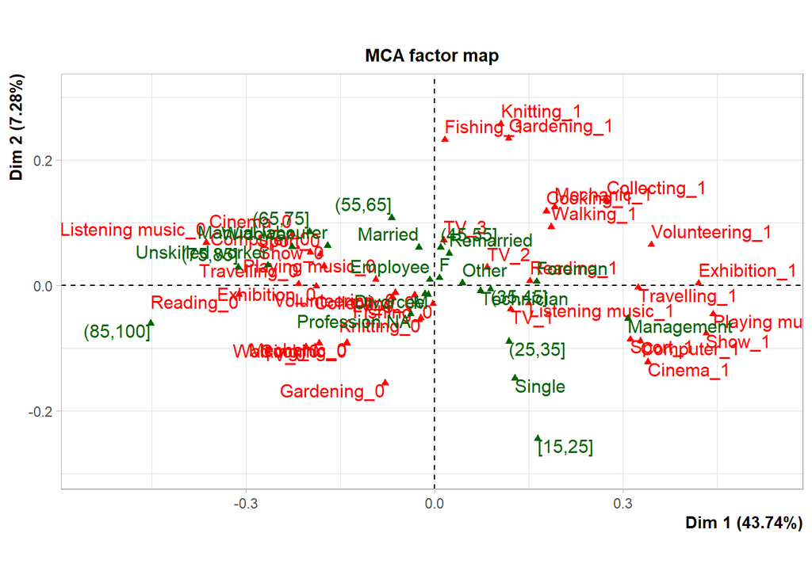

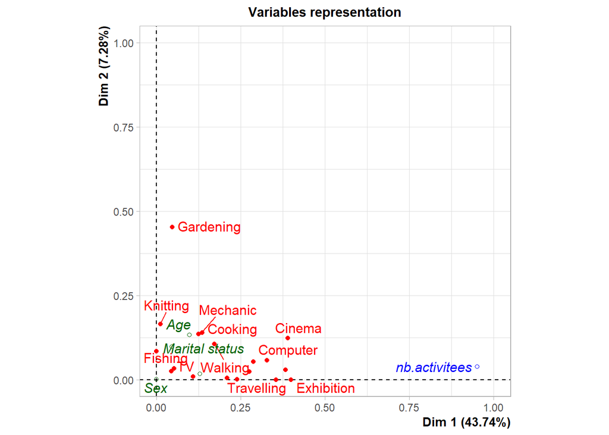

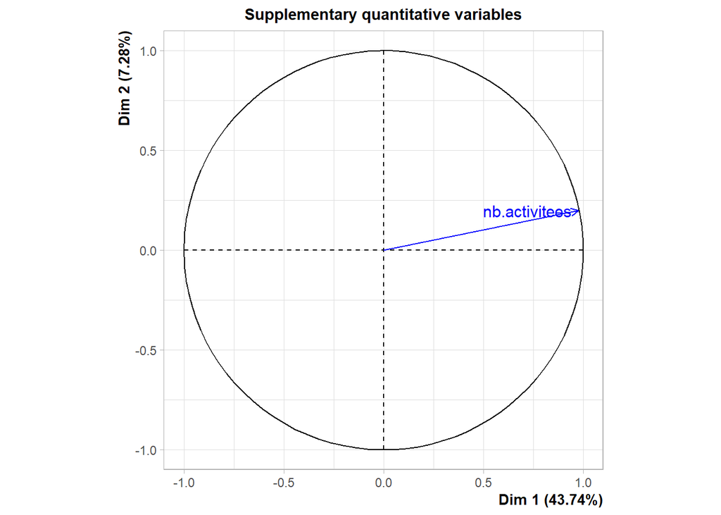

```r
MCA_hobbies <- MCA(hobbies,ncp = 5,quanti.sup=23,quali.sup=19:22,graph=T,method="Burt")
```

```r
#By looking at the MCA factor map it is possible to infer that there is a probable association between the categories of Knitting, Fishing and Gardening, and on the other hand, an association between the categories of Exhibition, Travelling, Playing Music, Show, Computer, Cinema and Sports.
```

5. Extract the proportion of inertia retained by the different MCA dimensions and visualize the percentages of inertia explained by each MCA dimensions. What is the cumulative percentage of inertia explained by the first two dimensions?

```r
#The eigenvalue explains the portion of inertia retained by different dimensions
get_eigenvalue(MCA_hobbies)
```

```
##          eigenvalue variance.percent cumulative.variance.percent
## Dim.1  0.0390898574        43.739216                    43.73922
## Dim.2  0.0065042783         7.277899                    51.01711
## Dim.3  0.0051871418         5.804102                    56.82122
## Dim.4  0.0039529439         4.423108                    61.24432
## Dim.5  0.0034175753         3.824063                    65.06839
## Dim.6  0.0031150294         3.485532                    68.55392
## Dim.7  0.0030828462         3.449521                    72.00344
## Dim.8  0.0028417688         3.179770                    75.18321
## Dim.9  0.0028137091         3.148372                    78.33158
## Dim.10 0.0024137688         2.700863                    81.03244
## Dim.11 0.0021616264         2.418731                    83.45118
## Dim.12 0.0020316944         2.273345                    85.72452
## Dim.13 0.0018933858         2.118586                    87.84311
## Dim.14 0.0018801464         2.103772                    89.94688
## Dim.15 0.0016646390         1.862632                    91.80951
## Dim.16 0.0014426008         1.614184                    93.42369
## Dim.17 0.0013938950         1.559685                    94.98338
## Dim.18 0.0013118330         1.467863                    96.45124
## Dim.19 0.0012227732         1.368210                    97.81945
## Dim.20 0.0010460114         1.170424                    98.98988
## Dim.21 0.0009027507         1.010124                   100.00000
```

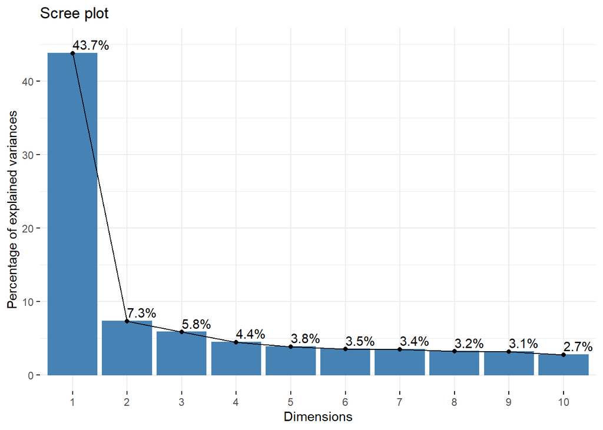

```r
#this plot allow us to visualize the percentages of inertia explained by each MCA dimensions
fviz_screeplot(MCA_hobbies, addlabels = TRUE, ylim = c(0, 45))
```

```r
# The cumulative percentage of inertia explained by the first two dimensions is of 43.7% plus 7.3%, which sums up to 51%
```

6. What are the 5 categories that contributes the most to the first dimension? and to the second?

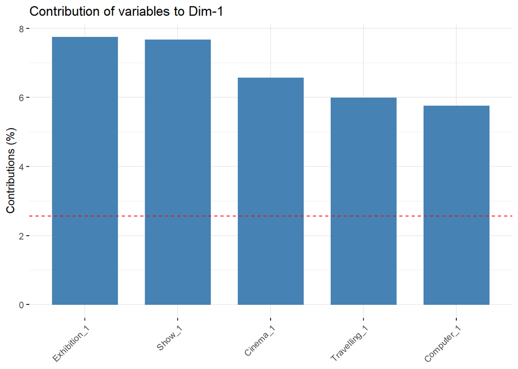

```r
#Top categories with the highest contribution in dimension 1 and 2, respectively
fviz_contrib(MCA_hobbies, choice = "var", axes = 1, top = 5)
```

[output not shown]